# Understanding Reliability

1/23/2022

## Preliminaries: Defining a Test Score as a Composite of Test Items

Let's start with a "test" score, \(X\), associated with a test-taker, indexed by the subscript \(j\). A test in this context consists of some fixed number of items, and the responses to these items are given ordinal scores. (In this sense we can also consider an attitudinal survey to be a type of test). So if we then let the subscript \(i\) index a test item, then

\[ X_j= \sum_{i=1}^{n_i} X_{ij} \] where \(n_i\) represents the total number of items on the test.

## Sources of "Error"

- The choice of items (\(n_i\))
- The sample of people taking the test (\(n_j\))
- All other facets of measurement that interact with people across replications.

## The Within-Person Model

\[\tag{1}X_j = \tau_j + e_j\] Each person's true score is the expected value over all possible tests of \(n_i\) items sampled from some universe of possible items \[\tag{2}E(X_j)=\tau_j\] and the "error" term is the difference between a single observed score and the unknown true score. \[\tag{3}e_j=X_j-E(X_j)\] Note that \(\tau_j\) and \(e\) are independent, and therefore uncorrelated, by definition.

## Vocabulary Test Thought Experiment

Derek and Ben each take 200 vocabulary tests, each test is a different random sample of 10 words.

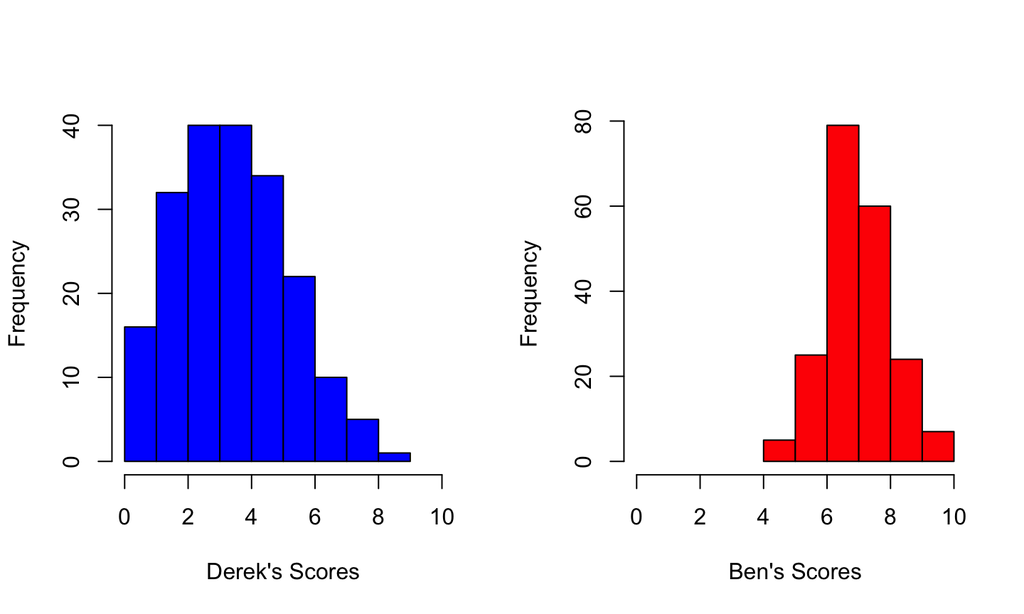

## Things to Notice

Derek's true score = 3.3, Ben's = 7.1 Derek's SD = 2, Ben's = 1 We are interested in the sampling variance of observed scores for each case \(j\), we want \[\sigma^2_{X_j}=\sigma^2_{\tau_j}+\sigma^2_{e_j}\] But since \(\tau_j\) is a constant, this expression reduces to \[\sigma^2_{X_j}=\sigma^2_{e_j}\] So in this example, not only is Derek's true score lower than Ben's true score, it is measured with more error.

## The Between-Person Model

We are going to express the fundamental equation of true score theory for a population of test-takers as

\[\tag{4}X = T + E\] This time, we are taking the variance not over replications within each individual test-taker, but *across* the observed scores of all individual test-takers.

\[\tag{5}\sigma^2_{X}=\sigma^2_{T}+\sigma^2_{E}\] Recall that when the model was within-person, each person's true score was a constant (\(\tau_j\)). But here, since we are taking variance *across* people, it is not. Also, \(\sigma^2_{E}\) can be thought of as \(E[\sigma^2_{e_j}]\)

## Back to the Vocabulary Test Example

Now assume that Derek and Ben were part of a sample of 100 students that took this test. The average score on this test was 6.4 with a standard deviation of 1.5.

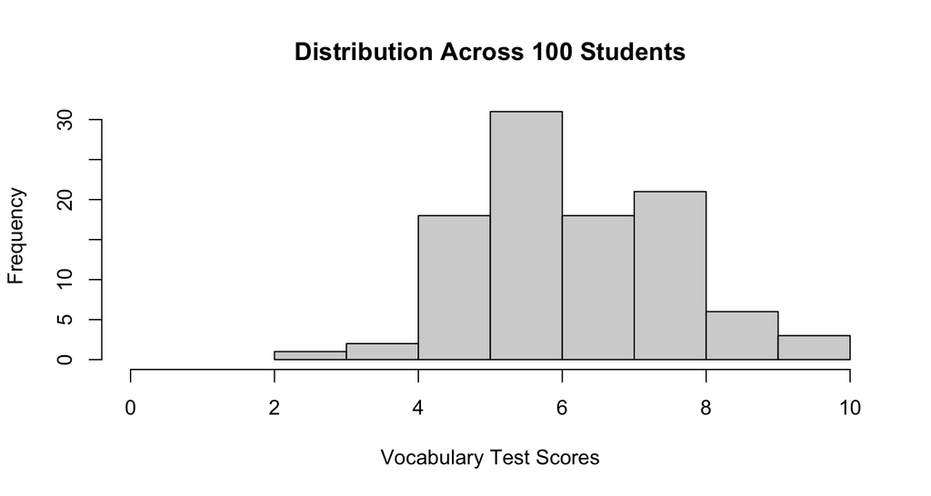

The variability we observe in these scores is caused by *both* true differences among students, and by measurement error.

## The Concept of Reliability

\[\tag{6}\rho^2_{XT}=\frac{\sigma^2_{T}}{\sigma^2_{X}}\]

-Reliability is the proportion of observed score variance that is true score variance

-It can also be interpreted as the squared correlation between observed scores and true scores

Here are three mathematically equivalent formulations of the concept

\[\rho^2_{XT}=\frac{\sigma^2_{XT}}{\sigma^2_{X}\sigma^2_{T}}=\frac{\sigma^2_{T}}{\sigma^2_{T}+\sigma^2_{E}}=1-\frac{\sigma^2_{E}}{\sigma^2_{X}}\]

## Parallel Test Forms 1

Let \(X, X^\prime\) represent two different test forms

The two test forms are parallel so long as

\(E(X)=E(X^\prime)=T\) and \(\sigma^2_{X} = \sigma^2_{X^\prime}\)

This means that the two forms are equivalent in difficulty and have the same observed score variance. What if we compute the correlation of scores across the common population taking the two test forms? This correlation would be

\[\rho_{XX^\prime}=\frac{\sigma_{XX^\prime}}{\sigma_{X}\sigma_{X^\prime}}\]

## Parallel Test Forms 2

Recall that \(X = T + E\) and \(X^\prime = T + E^\prime\), so \[\rho_{XX^\prime}=\frac{\sigma_{(T+E)(T+E^\prime)}}{\sigma_{X}\sigma_{X^\prime}},\] \[\rho_{XX^\prime}=\frac{\sigma_{TT}+\sigma_{TE}+\sigma_{TE^\prime}+\sigma_{EE^\prime}}{\sigma_{X}\sigma_{X^\prime}}.\] By assumption of the model, true scores and error scores are uncorrelated, and error scores are uncorrelated across parallel forms. So this expression reduces to

\[\rho_{XX^\prime}=\frac{\sigma_{TT}}{\sigma_{X}\sigma_{X^\prime}}.\]

## Parallel Test Forms 3

Now the covariance between true scores is just the variance of true scores, so \(\sigma_{TT}=\sigma^2_{T}\). And we defined parallel forms to have equal observed score variance, so \(\sigma_{X}=\sigma_{X^\prime}\) and \(\sigma_{X}\sigma_{X^\prime}=\sigma^2_{X}\). This means that \[\tag{7}\rho_{XX^\prime}=\frac{\sigma^2_{T}}{\sigma^2_{X}}.\] Hence \(\rho_{XX^\prime}=\rho^2_{XT}\).

## Spearman-Brown Formula

The Spearman-Brown "prophecy" formula can be use to predict the reliability of a test that consists of a composite from two smaller tests of the same length (i.e., same number of items).

\[\tag{8}\rho_{XX^\prime}=\frac{2\rho_{YY^\prime}}{1+\rho_{YY^\prime}}\]

In the expression above, the composite test score \(X=Y_1+Y_2\), and we define \(Y_1\) and \(Y_2\) to be parallel. So \(X=Y+Y^\prime\).

Think of \(\rho_{YY^\prime}\) as the "old" reliability of a test and \(\rho_{XX^\prime}\) as the "new" reliability we would predict if the test doubled in length.

## Visualizing Spearman-Brown

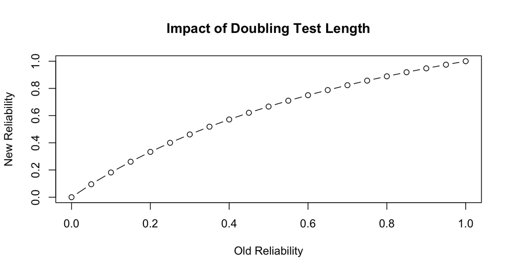

Notice the nonlinear relationship.

As base reliability increases, doubling the number of items is predicted to have less of an impact on the reliability of the new test.

## Generalized Spearman-Brown Formula

\[\tag{9}\rho_{XX^\prime}=\frac{k\rho_{YY^\prime}}{1+(k-1)\rho_{YY^\prime}}\]

This formula indicates how reliability is predicted to increase for any factor \(k\) increase in the number of items on the test.

## Split Half Approach to Estimating a Reliability Coefficient

So here is a strategy for getting an estimate of reliability if you only have a single test administration.

1. Split the test into two parallel halves
2. Correlate the scores on each half
3. Use the Spearman-Brown formula to get an estimate for reliability if the test was twice as long.

Problem: May not be obvious how to split the test

## Cronbach's Alpha Coefficient

\[ \tag{10}\alpha = \frac{m}{m-1} \left(1-\frac{\sum_{i=1}^{m}S^2_{X_i}}{S^2_{X}} \right) \]

Can be interpreted as the average of all possible ways the test could be split into two forms and correlated, correcting for the restriction in test length

## Unpacking the Expression for Alpha 1

\[ \alpha = \frac{m}{m-1} \left(1-\frac{\sum_{i=1}^{m}S^2_{X_i}}{S^2_{X}} \right) \]

1. The denominator, \(S^2_{X}\) represents the variance of the composite test score we get by adding together all the items on the test. Since each item can be thought of as a random variable, it follows that \(S^2_{X}=\sum_{i=1}^{m}\sum_{j=1}^{m}S_{X_iX_j}\). What this means is that the variance of the composite is the sum of all the item variances and item covariances. If there are \(m\) items, then variance of the sum of these items equals the sum of \(m^2\) variance and covariance terms.
2. The numerator, \(\sum_{i=1}^{m}S^2_{X_i}\), represents the sum of all \(m\) item variances. What it does *not* include are the item covariances.

## Unpacking the Expression for Alpha 2

\[ \alpha = \frac{m}{m-1} \left(1-\frac{\sum_{i=1}^{m}S^2_{X_i}}{S^2_{X}} \right) \]

When the ratio \(\frac{\sum_{i=1}^{m}S^2_{X_i}}{S^2_{X}}\) is small, this implies that the covariance between test items is large.

When the ratio \(\frac{\sum_{i=1}^{m}S^2_{X_i}}{S^2_{X}}\) is large, this implies that the covariance between test items is small.

## Original Motivation for Reliability: An Attenuated Correlation

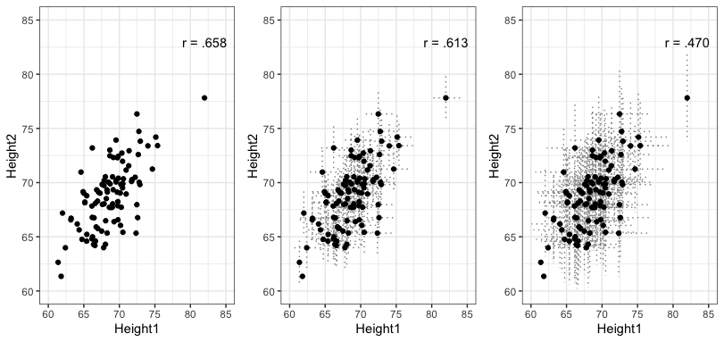

As More Error is Added, Correlation Decreases

## Uses of Reliability Coefficients

### Disattenuating a Correlation

\[\rho(X,Y)=\frac{\rho(\hat{X},\hat{Y})}{\sqrt{{\alpha_X}{\alpha_Y}}}\]

### Estimating the Standard Error of Measurement

\[SEM=\sqrt{1-\alpha}S_{X}\]

### Estimating True Scores

\[\tau_j={\alpha}{x_j}+({1-\alpha}){\bar{x}}\]

## Misconception #1: Alpha = internal consistency

To simplify, if all items have a variance of 1,  
\[\tag{11}\alpha=\frac{m\bar{r}}{1+(m-1)\bar{r}}\] With a little algebra, \[m=\frac{\alpha_{d}(1-\bar{r})}{\bar{r}(1-\alpha_{d})}\] where \(\alpha_{d}\) stands for "desired" alpha.

Bottom Line: Reliability, as estimated using \(\alpha\), is not solely a function of internal consistency.

For details, see Davenport, Davison, Liu & Love (2015, p. 5)

## Misconception #2: Alpha = Index of Unidimensionality

- Given some set of \(m\) items, we use eigenvalues to re-express the total variance in our \(m\) by \(m\) correlation matrix into \(m\) orthogonal variables such that each successive eigenvalue explains only variance that could not be explained by the previous eigenvalue.
- The total variance is an orthogonal re-expression of the correlation matrix, and will be equivalent to the total number of indicator variables, \(m\).
- Let \(\lambda_1\) represent the first eigenvalue extracted from a PCA.

## Misconception #2: Alpha = Index of Unidimensionality

The total variance explained by the first eigenvalue is

\[V=\frac{\lambda_1}{m}\]

Given this, DDLL point out a way that \(\alpha\) can be approximated:

\[\tag{12}\alpha \approx \frac{\bar{r}}{V}\]

DDLL provide three made-up examples where \(\alpha\) would provide misleading information if used as an index of unidimensionality. In two cases, \(\alpha\) is large (.91, .81) even though the data is clearly multidimensional; in another case, \(\alpha\) is small (.09) even though there is evidence of one (albeit weak) common factor.

## Misconception #3: Alpha = Consistency across Occasions

- What we actually would like to know is how a test score would change is the same test had been taken on a different temporal occasion: STABILITY
- The only way to estimate this would be to intentionally vary the occasion of measurement.
- The problem when measuring a cognitive attribute is that such estimates will likely be biased if the time between testings is too long, or will lead to fatigue if they time is too short.
- Alpha is an estimate for consistency across different versions of tests form sampled from the universe of possible items.

## An Empirical Example: Measuring 80s Music Fluency

- Data from a test given to 46 doctoral students in the University of Colorado's School of Education.
- Each of 20 items consists of the first 30 seconds of a song that was a top 10 hit from the 1980s.
- An item is scored as correct (1) if the student can name the title of the song or the artist. Otherwise it is scored as incorrect (0).
- So maximum total score is 20.

## Descriptive Statistics

```
   Min. 1st Qu.  Median    Mean 3rd Qu.    Max.
    1.0     3.0     6.5     7.7    11.0    19.0
```

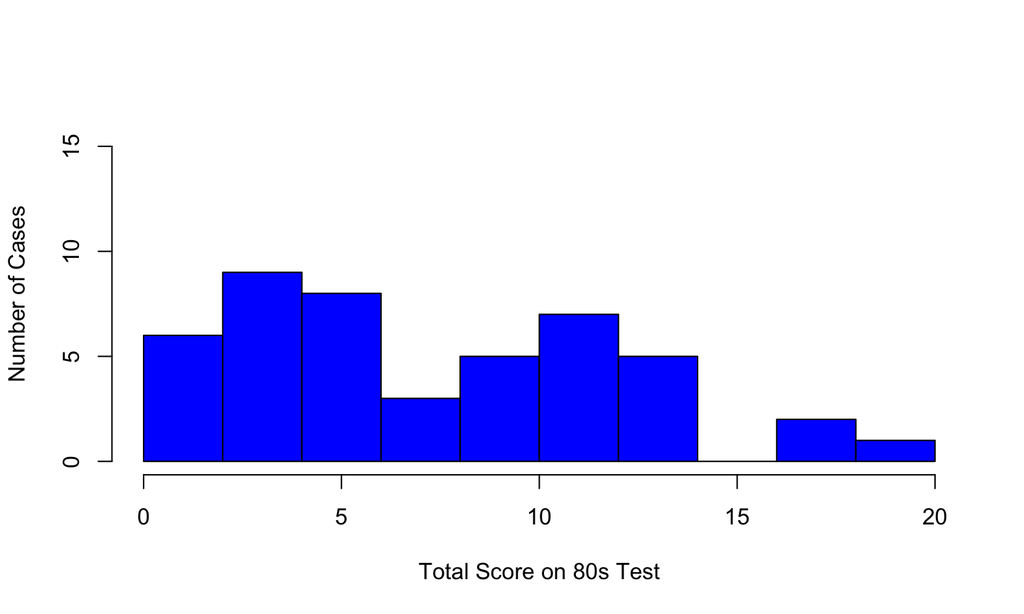

## Using alpha in the psych package

```r
library("psych")
x<-alpha(d)
#Standardized Alpha (Equivalent to Equation 11)
round(x$total$std.alpha,3)
```

```
[1] 0.873
```

```r
#Raw Alpha (Equivalent to Equation 5 in DDLL)
round(x$total$raw_alpha,3)
```

```
[1] 0.873
```

```r
#Average Interitem Correlation
round(x$total$average_r,3)
```

```
[1] 0.256
```

## Classical Item Statistics

```
            r.cor r.drop  mean    sd
J.Cougar    0.635  0.594 0.652 0.482
Flock       0.546  0.493 0.348 0.482
TTD         0.561  0.493 0.217 0.417
Wham        0.636  0.572 0.261 0.444
Marley      0.340  0.297 0.283 0.455
Madonna     0.236  0.198 0.717 0.455
Metallica   0.520  0.459 0.326 0.474
Tone.Loc    0.527  0.482 0.500 0.506
Big.Country 0.692  0.645 0.283 0.455
DM          0.446  0.403 0.283 0.455
Erasure     0.599  0.540 0.196 0.401
U2          0.452  0.406 0.739 0.444
Bon.Jovi    0.648  0.610 0.457 0.504
Cure        0.373  0.330 0.217 0.417
Idol        0.574  0.522 0.500 0.506
Band.Aid    0.420  0.365 0.130 0.341
Def.Leppard 0.694  0.642 0.304 0.465
Schilling   0.470  0.417 0.109 0.315
MJ          0.442  0.395 0.630 0.488
Prince      0.626  0.587 0.522 0.505
```

## Using DDLL's Alternate Expression for Alpha

Let's go ahead and apply DDLL's equation 3 (my equation 11) above

\[\alpha=\frac{m\bar{r}}{1+(m-1)\bar{r}}\]

to show that it gives the same reliability estimate we get using the alpha function.

```r
m<-ncol(d)
rbar<-x$total$average_r
round(m*rbar/(1+(m-1)*rbar),3)
```

```
[1] 0.873
```

## Using DDLL's Approximation Based on Eigevalue Ratio

- Now let's see if we can compute \(\alpha \approx \frac{\bar{r}}{V}\).
- We already know \(\bar{r}\) = 0.256
- We need to find \(V\).

```r
fpc<-principal(d,nfactors=1)
V<-fpc$values[1]/ncol(d)
round(V,3)
```

```
[1] 0.306
```

```r
round(rbar/V,3)
```

```
[1] 0.834
```

## A More Direct Evaluation of Dimensionality

- Let's have a closer look at the dimensionality of this 80s music test.

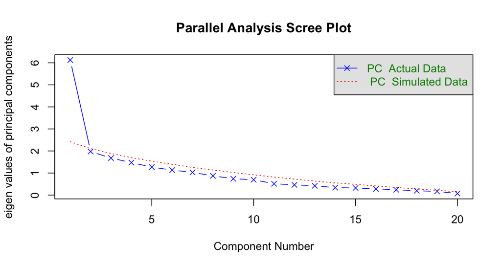

```
Parallel analysis suggests that the number of factors =  NA  and the number of components =  1
```

## Alpha as a Lower Bound Estimate

\(\alpha\) is not necessarily the same thing as \(\rho_{XT}\)

In general, \(\alpha \leq \rho_{XX^\prime}\)

For a proof, see Novick & Lewis (1967), pages 4-6

The original demonstration is due to Guttman (1945)

The Question: When will \(\alpha = \rho_{XX^\prime}\)?

## Relationships Between Test Items

- Consider any two test items, \(X_g\) and \(X_h\).
- Each item has been sampled from the same universe of items
- For each item,fundamental eqn of CTT holds, so
- \(X_g = T_g + E_g\) and \(X_h = T_h + E_h\).

Now express the true score for one item as a linear function of the other:

\[T_g = a_{gh} + b_{gh}T_{h}\]

## From tau-equivalent to essentially tau equivalent

\[T_g = a_{gh} + b_{gh}T_{h}\]

A test is *tau equivalent* when \(a_{gh}=0\) and \(b_{gh}=1\)

A test is *essentially tau equivalent* when \(a_{gh}\) can vary and \(b_{gh}=1\)

*If test items meet either of these conditions, \(\alpha = \rho_{XX^\prime}\)*

If \(a_{gh}\) and \(b_{gh}=1\) can vary, the test is called *congeneric*

In this case, \(\alpha < \rho_{XX^\prime}\)

## Another way to make distinctions in assumptions about "parallelism"

| Assumption | Expression |
| --- | --- |
| Strictly parallel | \(X_{ij} = T_j + E_j\) |
| Tau Equivalent | \(X_{ij} = T_j + E_{ij}\) |
| Essentual Tau Equivalent | \(X_{ij} = (a_i + T_j) + E_{ij}\) |
| Congeneric | \(X_{ij} = (a_i + B_i*T_j) + E_{ij}\) |